# Robust approaches to modelling fragile conservation biology: flexible solutions to non-normal, hierarchical, temporal, spatial, and phylogenetic data

Yefeng Yang, Jinming Pan, David Warton, Shinichi Nakagawa

10-03-2026

# 0 Code attribution

Parts of the diagnostic workflow and example code in this document are inspired by or adapted from:

Hartig, F. *Advanced Regression Models with R*.

This work is licensed under a Creative Commons Attribution–NonCommercial–ShareAlike 4.0 International License (CC BY-NC-SA 4.0).

The examples provided here modify and extend the original material by using simulated datasets and workflows tailored to demonstrate (temporal) autocorrelation, heteroscedasticity, and outliers diagnostics.

# 1 Simulate temporally autocorrelated ecological data

We simulate species richness driven by temperature, with AR(1) temporal dependence.

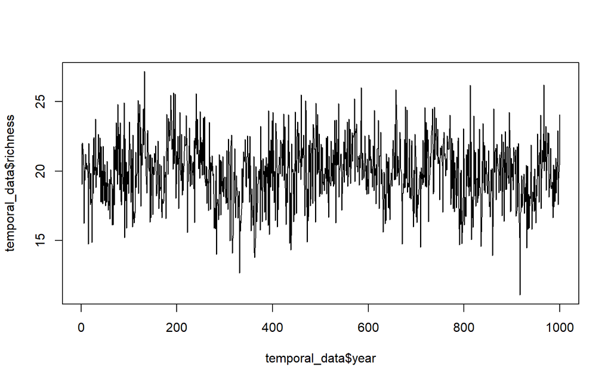

```r
set.seed(2026)

AR1sim <- function(n, phi, sigma = 1){
  x <- numeric(n)
  x[1] <- rnorm(1,0,sigma)
  for(i in 2:n){
    x[i] <- phi * x[i-1] + rnorm(1,0,sigma)
  }
  return(x)
}

n <- 1000
year <- 1:n

temperature <- scale(rnorm(n, 15, 3))

#  temporal autocorrelation
epsilon <- AR1sim(n, phi = 0.9, sigma = 0.5)

richness <- 20 + 2*temperature + epsilon

temporal_data <- data.frame(
  year = year,
  temperature = as.numeric(temperature),
  richness = richness
)

plot(temporal_data$year, temporal_data$richness, type="l")
```

# 2 Fit a model ignoring the structured ecological trend

```r
ignore_trend = lm(richness ~ 1, data = temporal_data)
summary(ignore_trend)
```

```
##
## Call:
## lm(formula = richness ~ 1, data = temporal_data)
##
## Residuals:
##     Min      1Q  Median      3Q     Max
## -8.8622 -1.5247  0.0568  1.4462  7.2554
##
## Coefficients:
##             Estimate Std. Error t value Pr(>|t|)
## (Intercept) 19.92457    0.07224   275.8   <2e-16 ***
## ---
## Signif. codes:  0 '***' 0.001 '**' 0.01 '*' 0.05 '.' 0.1 ' ' 1
##
## Residual standard error: 2.284 on 999 degrees of freedom
```

Check the residuals:

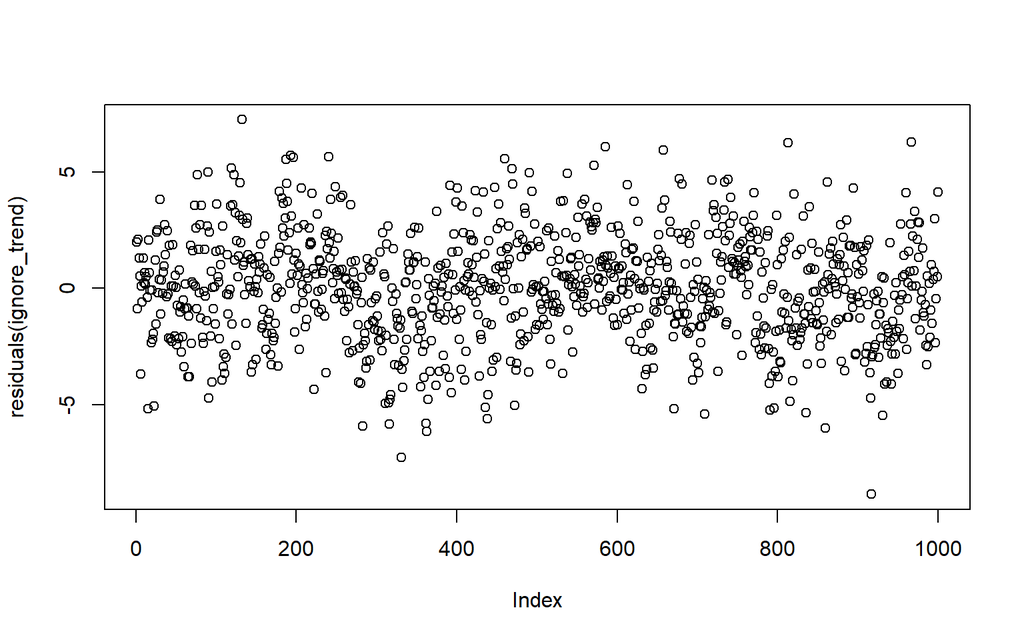

```r
plot(residuals(ignore_trend))
```

Have a look at the correlation between richness as a function of their lag (temporal distance):

```r
library(DHARMa)
```

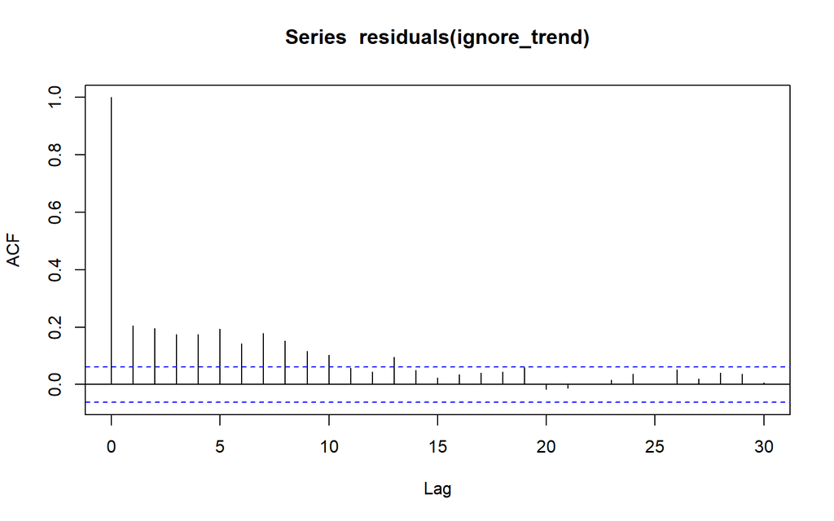

```r
acf(residuals(ignore_trend), type = "correlation", plot = T)
```

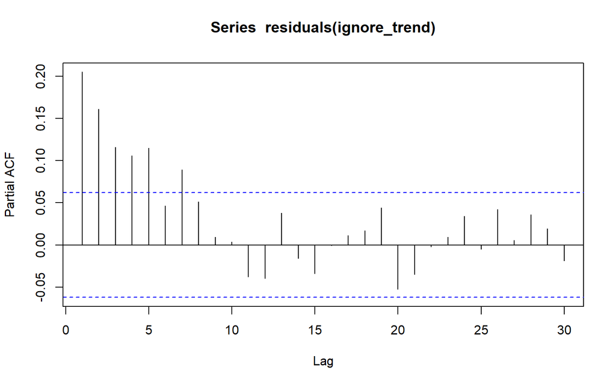

```r
pacf(residuals(ignore_trend), plot = T)
```

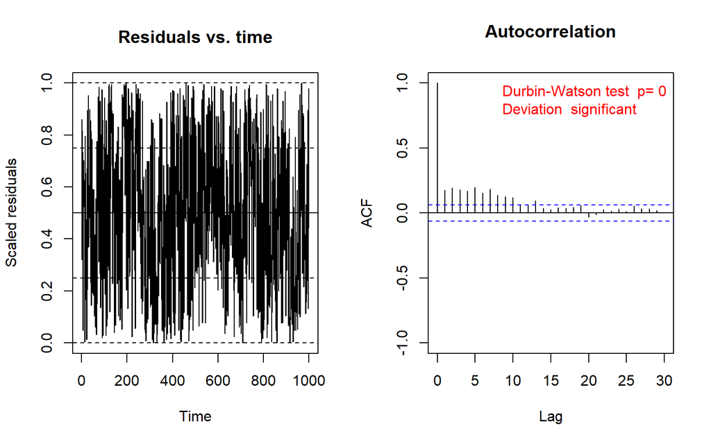

```
##
##  Durbin-Watson test
##
## data:  simulationOutput$scaledResiduals ~ 1
## DW = 1.6459, p-value = 2.097e-08
## alternative hypothesis: true autocorrelation is not 0
```

```r
testTemporalAutocorrelation(ignore_trend, time = temporal_data$year)
```

# 3 Fit a model capturing the ecological trend

This model accounts for temporal trend but does not model temporal dependence.

```r
mod_trend = lm(richness ~ temperature, data = temporal_data)
summary(mod_trend)
```

```
##
## Call:
## lm(formula = richness ~ temperature, data = temporal_data)
##
## Residuals:
##     Min      1Q  Median      3Q     Max
## -3.7551 -0.7502 -0.0138  0.8451  3.2166
##
## Coefficients:
##             Estimate Std. Error t value Pr(>|t|)
## (Intercept) 19.92457    0.03576  557.19   <2e-16 ***
## temperature  1.98520    0.03578   55.49   <2e-16 ***
## ---
## Signif. codes:  0 '***' 0.001 '**' 0.01 '*' 0.05 '.' 0.1 ' ' 1
##
## Residual standard error: 1.131 on 998 degrees of freedom
## Multiple R-squared:  0.7552, Adjusted R-squared:  0.755
## F-statistic:  3079 on 1 and 998 DF,  p-value: < 2.2e-16
```

```r
library(nlme)
mod_trend2 <- gls(
  richness ~ temperature,
  data = temporal_data
)
summary(mod_trend2)
```

```
## Generalized least squares fit by REML
##   Model: richness ~ temperature
##   Data: temporal_data
##        AIC    BIC    logLik
##   3097.383 3112.1 -1545.692
##
## Coefficients:
##                 Value  Std.Error  t-value p-value
## (Intercept) 19.924571 0.03575918 557.1875       0
## temperature  1.985204 0.03577708  55.4882       0
##
##  Correlation:
##             (Intr)
## temperature 0
##
## Standardized residuals:
##         Min          Q1         Med          Q3         Max
## -3.32075490 -0.66340322 -0.01220586  0.74737457  2.84455330
##
## Residual standard error: 1.130805
## Degrees of freedom: 1000 total; 998 residual
```

Given that `gls` is not a `DHARMa` object, we now use `glmmTMB` for illustration:

```r
library(glmmTMB)
mod_trend3 = glmmTMB(richness ~ ar1(factor(year) + 0 | 1), data = temporal_data) # `1` can be replaced by `grp` indicating multiple time series
summary(mod_trend3)
```

```
##  Family: gaussian  ( identity )
## Formula:          richness ~ ar1(factor(year) + 0 | 1)
## Data: temporal_data
##
##      AIC      BIC   logLik deviance df.resid
##   4493.1   4502.9  -2244.5   4489.1      998
##
##
## Dispersion estimate for gaussian family (sigma^2): 5.21
##
## Conditional model:
##             Estimate Std. Error z value Pr(>|z|)
## (Intercept)  19.9246     0.0722   275.9   <2e-16 ***
## ---
## Signif. codes:  0 '***' 0.001 '**' 0.01 '*' 0.05 '.' 0.1 ' ' 1
```

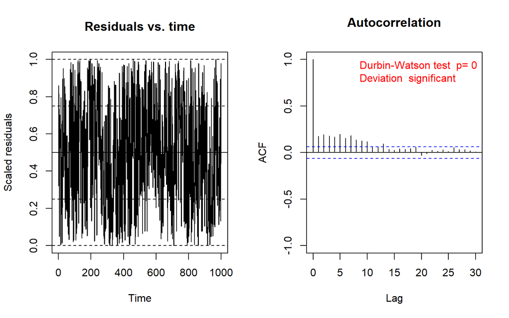

```
##
##  Durbin-Watson test
##
## data:  simulationOutput$scaledResiduals ~ 1
## DW = 1.646, p-value = 2.107e-08
## alternative hypothesis: true autocorrelation is not 0
```

```r
testTemporalAutocorrelation(mod_trend3, time = temporal_data$year)
```

Fit a model accounting for both temporal trend and temporal dependence:

```r
# using gls
mod_trend4 <- gls(
  richness ~ temperature,
  corr = corAR1(0.9, form = ~ 1),
  data = temporal_data
)
summary(mod_trend4)
```

```
## Generalized least squares fit by REML
##   Model: richness ~ temperature
##   Data: temporal_data
##        AIC     BIC    logLik
##   1399.057 1418.68 -695.5287
##
## Correlation Structure: AR(1)
##  Formula: ~1
##  Parameter estimate(s):
##       Phi
## 0.9055215
##
## Coefficients:
##                 Value Std.Error  t-value p-value
## (Intercept) 19.928897 0.1601353 124.4504       0
## temperature  1.988704 0.0112399 176.9326       0
##
##  Correlation:
##             (Intr)
## temperature -0.002
##
## Standardized residuals:
##         Min          Q1         Med          Q3         Max
## -3.30588263 -0.66366522 -0.01672808  0.74095528  2.81994165
##
## Residual standard error: 1.138332
## Degrees of freedom: 1000 total; 998 residual
```

```r
#using glmmTMB
mod_trend5 = glmmTMB(richness ~ temperature + ar1(0 + factor(year) | 1), data = temporal_data)
summary(mod_trend5)
```

```
##  Family: gaussian  ( identity )
## Formula:          richness ~ temperature + ar1(0 + factor(year) | 1)
## Data: temporal_data
##
##      AIC      BIC   logLik deviance df.resid
##   3087.7   3102.5  -1540.9   3081.7      997
##
##
## Dispersion estimate for gaussian family (sigma^2): 1.28
##
## Conditional model:
##             Estimate Std. Error z value Pr(>|z|)
## (Intercept) 19.92457    0.03572   557.7   <2e-16 ***
## temperature  1.98520    0.03574    55.5   <2e-16 ***
## ---
## Signif. codes:  0 '***' 0.001 '**' 0.01 '*' 0.05 '.' 0.1 ' ' 1
```

# 4 Residual diagnostics with DHARMa

The diagnostic plots evaluate whether residuals behave as expected under the fitted model:

We look for

- uniform residual distribution
- no strong structure in residual plots
- no systematic trends

If temporal autocorrelation exists, residuals often show structured deviations from randomness.

For the diagnostic of the model accounting for temporal trend but does not model temporal dependence (`mod_trend`):

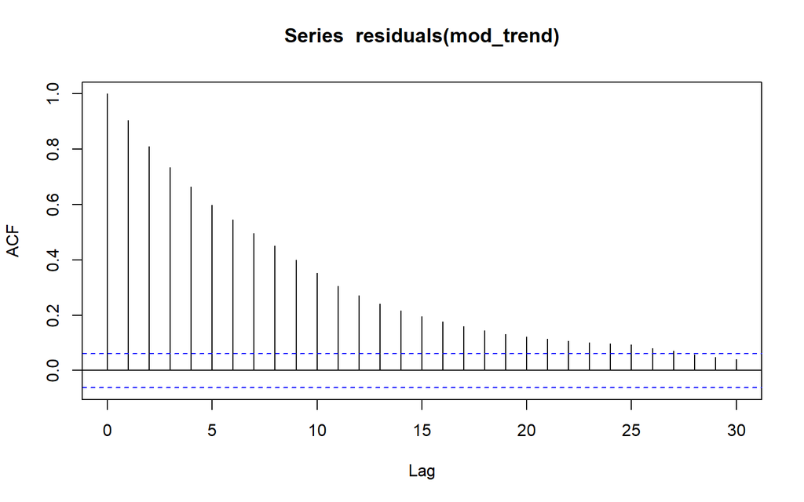

```r
acf(residuals(mod_trend), type = "correlation", plot = T)
```

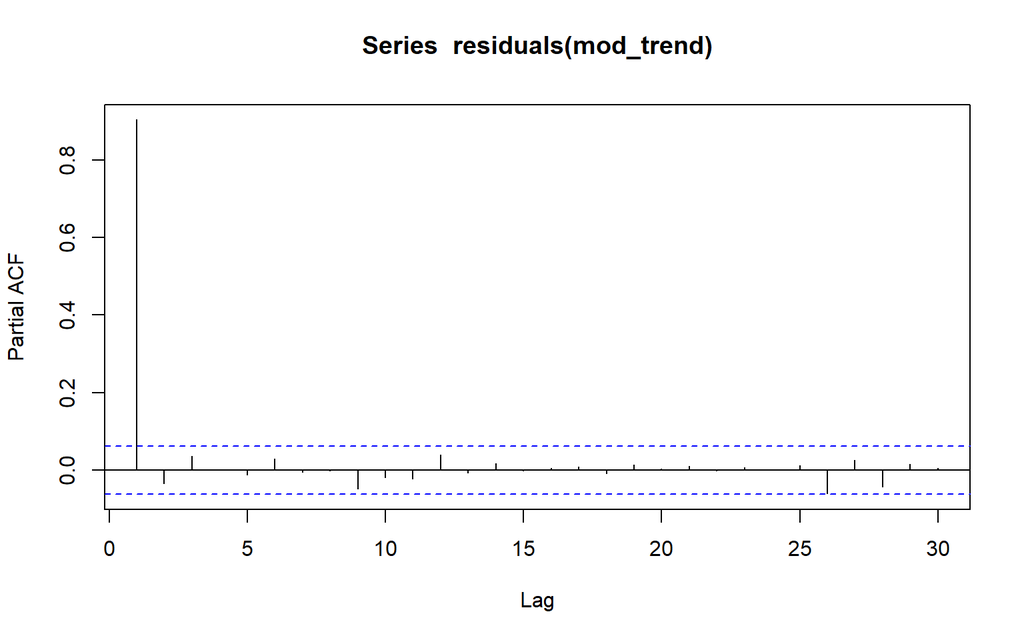

```r
pacf(residuals(mod_trend), plot = T)
```

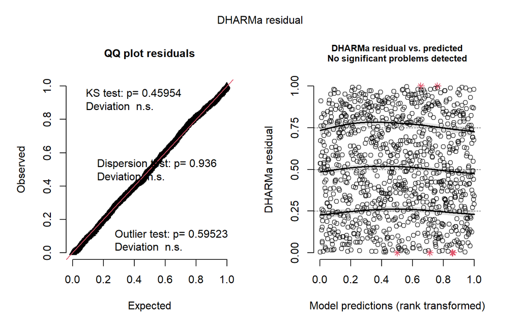

```r
library(DHARMa)
res <- simulateResiduals(mod_trend)
plot(res)
```

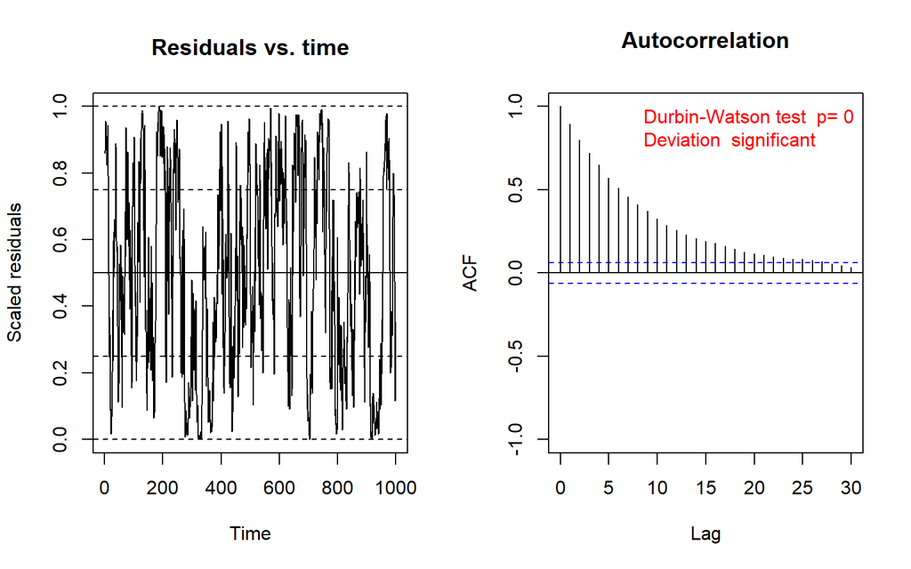

```
##
##  Durbin-Watson test
##
## data:  simulationOutput$scaledResiduals ~ 1
## DW = 0.21232, p-value < 2.2e-16
## alternative hypothesis: true autocorrelation is not 0
```

```r
testTemporalAutocorrelation(res, time = temporal_data$year)
```

For the diagnostic of the model accounting for temporal dependence but does not model temporal trend (`mod_trend3`):

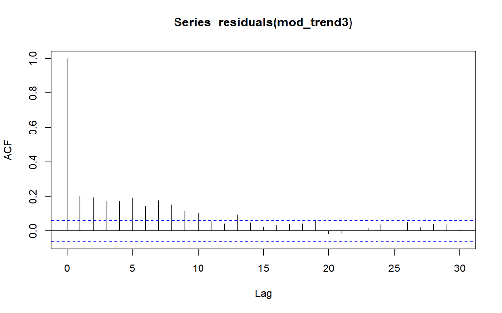

```r
acf(residuals(mod_trend3), type = "correlation", plot = T)
```

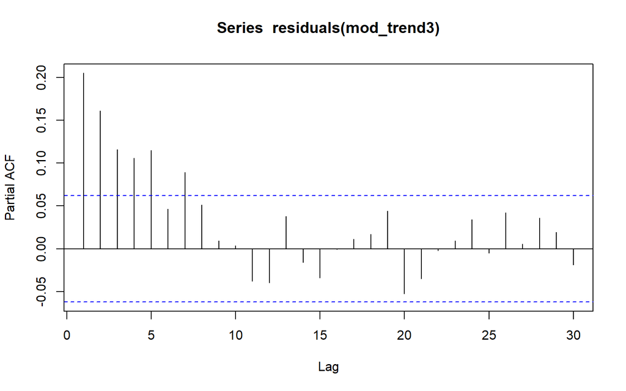

```r
pacf(residuals(mod_trend3), plot = T)
```

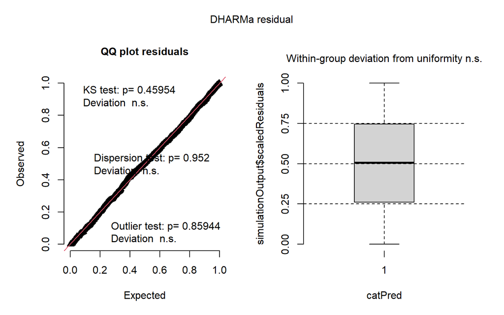

```r
res <- simulateResiduals(mod_trend3)
plot(res)
```

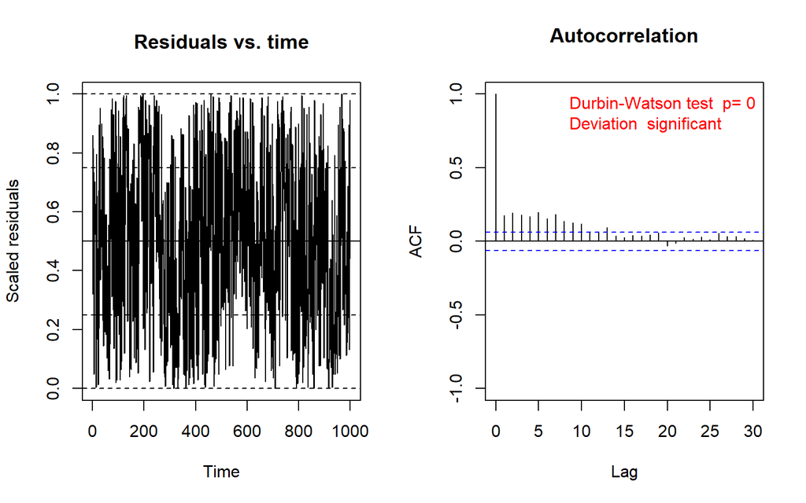

```
##
##  Durbin-Watson test
##
## data:  simulationOutput$scaledResiduals ~ 1
## DW = 1.646, p-value = 2.107e-08
## alternative hypothesis: true autocorrelation is not 0
```

```r
testTemporalAutocorrelation(res, time = temporal_data$year)
```

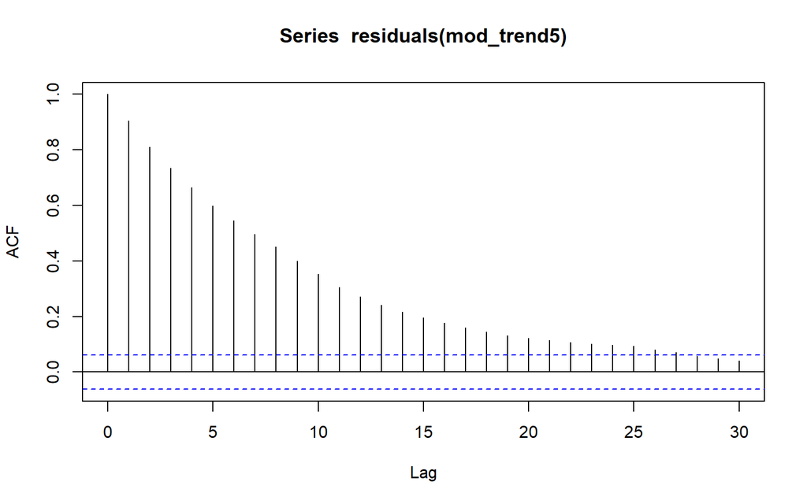

```r
acf(residuals(mod_trend5), type = "correlation", plot = T)
```

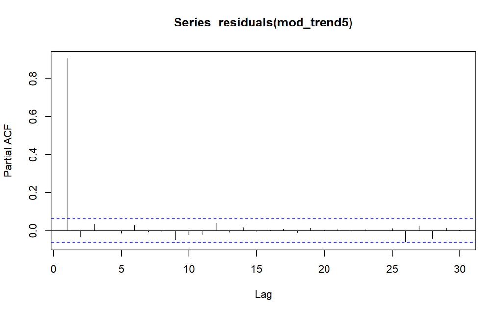

```r
pacf(residuals(mod_trend5), plot = T)
```

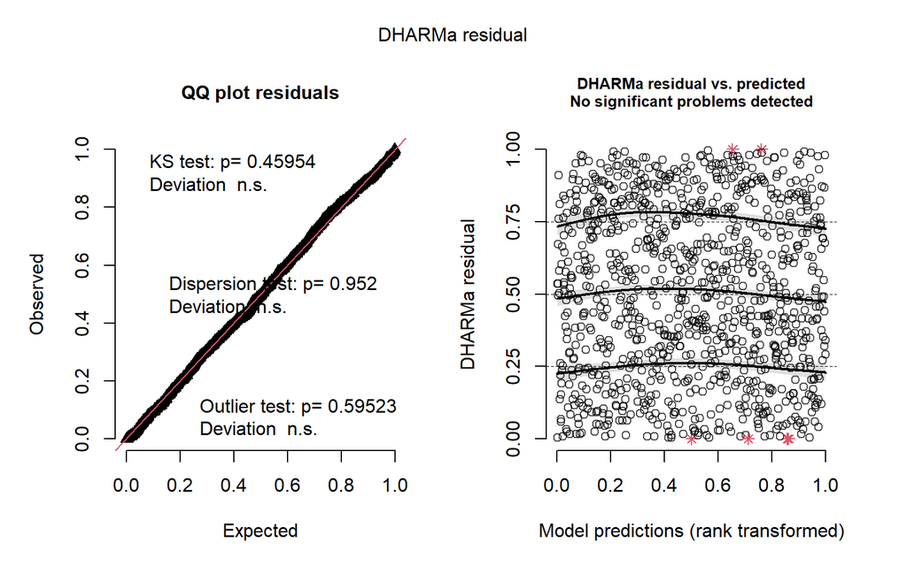

```r
res <- simulateResiduals(mod_trend5)
plot(res)
```

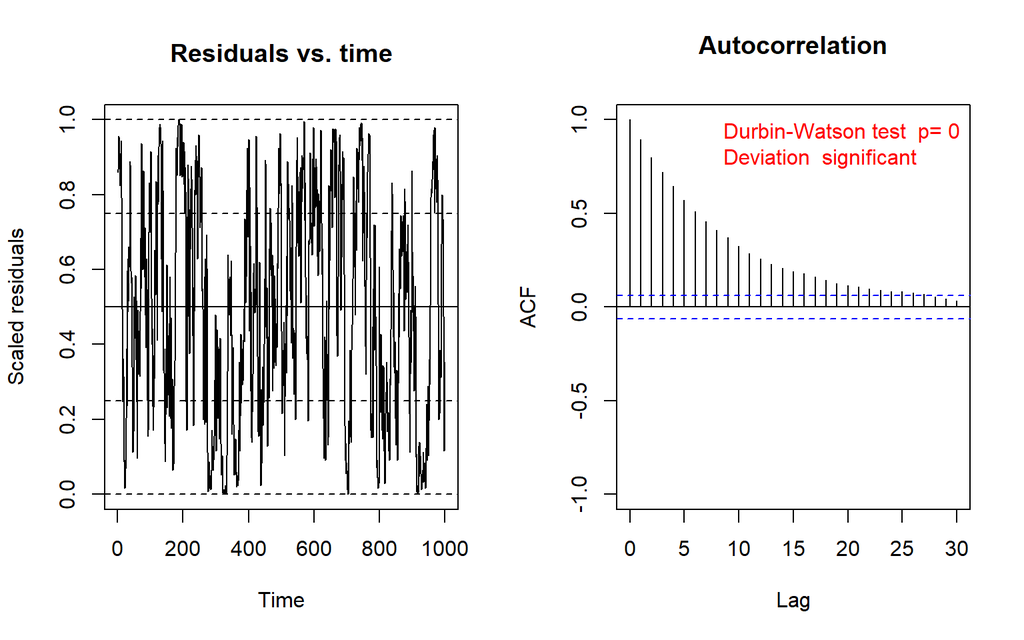

```
##
##  Durbin-Watson test
##
## data:  simulationOutput$scaledResiduals ~ 1
## DW = 0.21245, p-value < 2.2e-16
## alternative hypothesis: true autocorrelation is not 0
```

```r
testTemporalAutocorrelation(res, time = temporal_data$year)
```

**Important interpretation principle:**

We do not recommend relying solely on the P-value obtained from the `DHARMa` package. We encourage evaluate:

- magnitude of the autocorrelation statistic
- residual plots
- ecological plausibility

# 5 Diagnosing heteroscedasticity

Let’s visually and statistically diagonise potential heteroscedasticity of the fitted model:

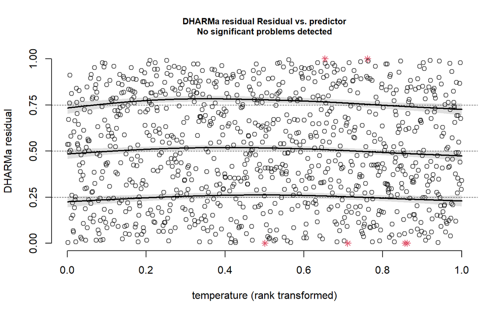

```r
# visual
plotResiduals(res, temporal_data$temperature)
```

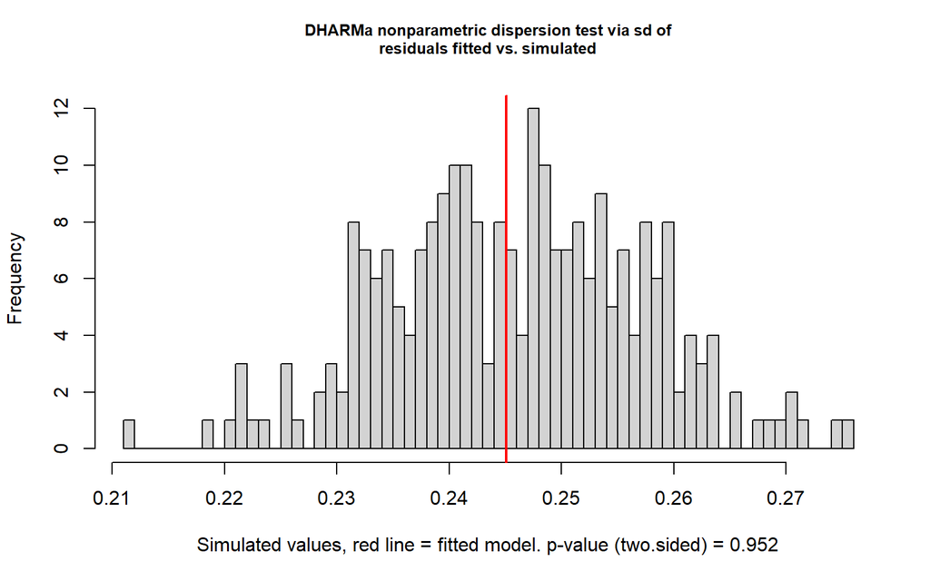

```
##
##  DHARMa nonparametric dispersion test via sd of residuals fitted vs.
##  simulated
##
## data:  simulationOutput
## dispersion = 0.99741, p-value = 0.952
## alternative hypothesis: two.sided
```

```r
# statistical
testDispersion(res)
```

# 6 Detecting outliers

Let’s visually and statistically diagonise potential outliers of the fitted model:

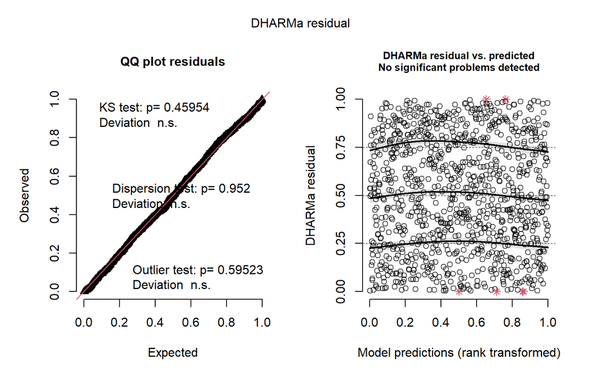

```r
# visual
plot(res, quantreg = TRUE)
```

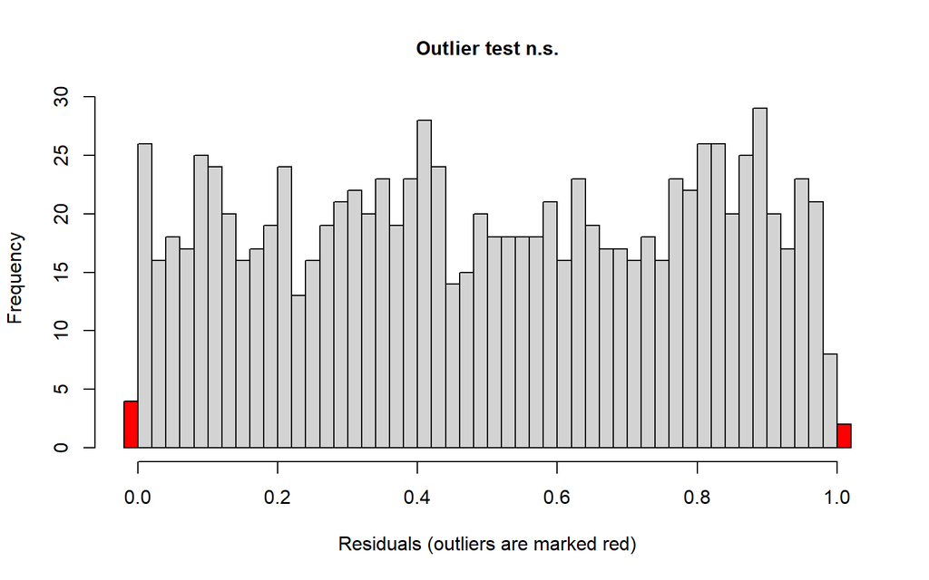

```
##
##  DHARMa outlier test based on exact binomial test with approximate
##  expectations
##
## data:  res
## outliers at both margin(s) = 6, observations = 1000, p-value = 0.5952
## alternative hypothesis: true probability of success is not equal to 0.007968127
## 95 percent confidence interval:
##  0.002204982 0.013013423
## sample estimates:
## frequency of outliers (expected: 0.00796812749003984 )
##                                                  0.006
```

```r
# statistical
testOutliers(res)
```

# Declaration

This document contains adapted material inspired by examples from Florian Hartig’s *Advanced Regression Models with R*.

Licensed under Creative Commons Attribution–NonCommercial–ShareAlike 4.0. Adaptations in this document include new simulated datasets (completely different data-generation process), modified code examples, and integration with DHARMa-based diagnostics.

# Package information

```r
subset(data.frame(sessioninfo::package_info()), attached==TRUE, c(package, loadedversion))
```

```
##         package loadedversion
## DHARMa   DHARMa         0.4.7
## glmmTMB glmmTMB         1.1.3
## nlme       nlme       3.1-151
```